# Netflix data analysis using Python.

Objective - The main objective is to perform Exploratory data analysis over Netflix data which include the details of TV shows and Movies. Analyze the given dataset to answer set of business questions client wants to know.

Data source- Kaggle.com This dataset consists of tv shows and movies available on Netflix as of 2019. The dataset is collected from Flixable which is a third-party Netflix search engine.

Project Roadmap

1. Ask- Collect stakeholder requirement and business questions.
2. Prepare- Validate business requirement and download data set.
3. Process- Perform Exploratory data analysis and make it ready for analysis.
4. Analyze- Analyze the data to answer set of business questions.
5. Share- Document and represent the findings and share it with stakeholders.

Business Questions client want to know are:-

1. Get detail for "House of Cards" and who is the director of the show.
2. Highest number of TV shows and movies released by years, Visualize result.
3. How many Movies and TV Show we have in dataset.
4. In The year 2000 how many movies are releases, display their details.
5. Show number of TV Shows released in India only and also get their title.
6. Show number of TV Shows released in India only and also get their title.
7. Show Top 10 Directors, Who gave the highest number of releases to Netflix.
8. Show all the Records, where "Category is Movie and Type is Comedies" or "Country is United Kingdom".
9. Get detail of Actor Tom Cruise, in home many Movies/Shows he was present.
10. Count of all unique Ratings.
11. Get the count of TV-14 rating Movies in Canada.
12. After 2018 how many TV Shows got "R" rating.
13. Maximum Seasons in TV Shows.
14. Maximum duration in Movie.
15. Country with release of maximum number of TV Show.
16. Country with release of maximum number of Movies.
17. Find total number of Drama Movies and display records.
18. Find total number of Kids TV Show and display records.
19. Find the number of Comedy Movies released for family and kids in India only and display their title.
20. Find the number of adult movies released in India only along with title and duration of movie.
21. Find Adventure and Thriller movies released in India only along with title and duration of movie.

Analzyed by - Mohammad Juned Khan

```python
# import basic libraries
import pandas as pd
import numpy as np
import seaborn as sns
import matplotlib.pyplot as plt
%matplotlib inline
```

```python
# import Netflix dataset
data=pd.read_csv("Netflix_dataset.csv")
# view to rows of data set
data.head(5)
```

|  | Show_Id | Category | Title | Director | Cast | Country | Release_Date | Rating | Duration | Type | Description |
| --- | --- | --- | --- | --- | --- | --- | --- | --- | --- | --- | --- |
| 0 | s1 | TV Show | 3% | NaN | João Miguel, Bianca Comparato, Michel Gomes, R... | Brazil | August 14, 2020 | TV-MA | 4 Seasons | International TV Shows, TV Dramas, TV Sci-Fi &... | In a future where the elite inhabit an island ... |
| 1 | s2 | Movie | 07:19 | Jorge Michel Grau | Demián Bichir, Héctor Bonilla, Oscar Serrano, ... | Mexico | December 23, 2016 | TV-MA | 93 min | Dramas, International Movies | After a devastating earthquake hits Mexico Cit... |
| 2 | s3 | Movie | 23:59 | Gilbert Chan | Tedd Chan, Stella Chung, Henley Hii, Lawrence ... | Singapore | December 20, 2018 | R | 78 min | Horror Movies, International Movies | When an army recruit is found dead, his fellow... |
| 3 | s4 | Movie | 9 | Shane Acker | Elijah Wood, John C. Reilly, Jennifer Connelly... | United States | November 16, 2017 | PG-13 | 80 min | Action & Adventure, Independent Movies, Sci-Fi... | In a postapocalyptic world, rag-doll robots hi... |
| 4 | s5 | Movie | 21 | Robert Luketic | Jim Sturgess, Kevin Spacey, Kate Bosworth, Aar... | United States | January 1, 2020 | PG-13 | 123 min | Dramas | A brilliant group of students become card-coun... |

## Perform Exploratory data analysis first

```python
# top 5 records
data.head()
```

|  | Show_Id | Category | Title | Director | Cast | Country | Release_Date | Rating | Duration | Type | Description |
| --- | --- | --- | --- | --- | --- | --- | --- | --- | --- | --- | --- |
| 0 | s1 | TV Show | 3% | NaN | João Miguel, Bianca Comparato, Michel Gomes, R... | Brazil | August 14, 2020 | TV-MA | 4 Seasons | International TV Shows, TV Dramas, TV Sci-Fi &... | In a future where the elite inhabit an island ... |
| 1 | s2 | Movie | 07:19 | Jorge Michel Grau | Demián Bichir, Héctor Bonilla, Oscar Serrano, ... | Mexico | December 23, 2016 | TV-MA | 93 min | Dramas, International Movies | After a devastating earthquake hits Mexico Cit... |
| 2 | s3 | Movie | 23:59 | Gilbert Chan | Tedd Chan, Stella Chung, Henley Hii, Lawrence ... | Singapore | December 20, 2018 | R | 78 min | Horror Movies, International Movies | When an army recruit is found dead, his fellow... |
| 3 | s4 | Movie | 9 | Shane Acker | Elijah Wood, John C. Reilly, Jennifer Connelly... | United States | November 16, 2017 | PG-13 | 80 min | Action & Adventure, Independent Movies, Sci-Fi... | In a postapocalyptic world, rag-doll robots hi... |
| 4 | s5 | Movie | 21 | Robert Luketic | Jim Sturgess, Kevin Spacey, Kate Bosworth, Aar... | United States | January 1, 2020 | PG-13 | 123 min | Dramas | A brilliant group of students become card-coun... |

```python
#bottom 5 records
data.tail()
```

|  | Show_Id | Category | Title | Director | Cast | Country | Release_Date | Rating | Duration | Type | Description |
| --- | --- | --- | --- | --- | --- | --- | --- | --- | --- | --- | --- |
| 7784 | s7783 | Movie | Zozo | Josef Fares | Imad Creidi, Antoinette Turk, Elias Gergi, Car... | Sweden, Czech Republic, United Kingdom, Denmar... | October 19, 2020 | TV-MA | 99 min | Dramas, International Movies | When Lebanon's Civil War deprives Zozo of his ... |
| 7785 | s7784 | Movie | Zubaan | Mozez Singh | Vicky Kaushal, Sarah-Jane Dias, Raaghav Chanan... | India | March 2, 2019 | TV-14 | 111 min | Dramas, International Movies, Music & Musicals | A scrappy but poor boy worms his way into a ty... |
| 7786 | s7785 | Movie | Zulu Man in Japan | NaN | Nasty C | NaN | September 25, 2020 | TV-MA | 44 min | Documentaries, International Movies, Music & M... | In this documentary, South African rapper Nast... |
| 7787 | s7786 | TV Show | Zumbo's Just Desserts | NaN | Adriano Zumbo, Rachel Khoo | Australia | October 31, 2020 | TV-PG | 1 Season | International TV Shows, Reality TV | Dessert wizard Adriano Zumbo looks for the nex... |
| 7788 | s7787 | Movie | ZZ TOP: THAT LITTLE OL' BAND FROM TEXAS | Sam Dunn | NaN | United Kingdom, Canada, United States | March 1, 2020 | TV-MA | 90 min | Documentaries, Music & Musicals | This documentary delves into the mystique behi... |

```python
# shape of dataset
data.shape
```

```
(7789, 11)
```

```python
# total number of elements in dataset
data.size
```

```
85679
```

```python
#list columns in dataset
data.columns
```

```
Index(['Show_Id', 'Category', 'Title', 'Director', 'Cast', 'Country',
       'Release_Date', 'Rating', 'Duration', 'Type', 'Description'],
      dtype='object')
```

```python
#data type of columns
data.dtypes
```

```
Show_Id         object
Category        object
Title           object
Director        object
Cast            object
Country         object
Release_Date    object
Rating          object
Duration        object
Type            object
Description     object
dtype: object
```

```python
# more information about dataset.
#such as index, number of columns, data type of each columns, non null values in each columns and memory usage.
data.info()
```

```
<class 'pandas.core.frame.DataFrame'>
RangeIndex: 7789 entries, 0 to 7788
Data columns (total 11 columns):
 #   Column        Non-Null Count  Dtype
---  ------        --------------  -----
 0   Show_Id       7789 non-null   object
 1   Category      7789 non-null   object
 2   Title         7789 non-null   object
 3   Director      5401 non-null   object
 4   Cast          7071 non-null   object
 5   Country       7282 non-null   object
 6   Release_Date  7779 non-null   object
 7   Rating        7782 non-null   object
 8   Duration      7789 non-null   object
 9   Type          7789 non-null   object
 10  Description   7789 non-null   object
dtypes: object(11)
memory usage: 669.5+ KB
```

```python
# Descriptive
data.describe(include="all")
```

[output not shown]

Check and remove duplicate records from the dataset.

```python
# check for duplicate records in data set and remove it.
data[data.duplicated()]
```

|  | Show_Id | Category | Title | Director | Cast | Country | Release_Date | Rating | Duration | Type | Description |
| --- | --- | --- | --- | --- | --- | --- | --- | --- | --- | --- | --- |
| 6300 | s684 | Movie | Backfire | Dave Patten | Black Deniro, Byron "Squally" Vinson, Dominic ... | United States | April 5, 2019 | TV-MA | 97 min | Dramas, Independent Movies, Thrillers | When two would-be robbers accidentally kill a ... |
| 6622 | s6621 | Movie | The Lost Okoroshi | Abba T. Makama | Seun Ajayi, Judith Audu, Tope Tedela, Ifu Enna... | Nigeria | September 4, 2020 | TV-MA | 94 min | Comedies, Dramas, Independent Movies | A disillusioned security guard transforms into... |

```python
# we have two duplicate records and now remove it
data.drop_duplicates(inplace=True)
```

```python
#now cross check for duplicate records
data[data.duplicated()]
```

|  | Show_Id | Category | Title | Director | Cast | Country | Release_Date | Rating | Duration | Type | Description |
| --- | --- | --- | --- | --- | --- | --- | --- | --- | --- | --- | --- |

```python
# shape of data after removing duplicate data. previous shape (7789, 11)
data.shape
```

```
(7787, 11)
```

Check for null values. Show it in Heat-map using seaborn

```python
# Get count of null values in each columns.
data.isnull().sum()
```

```
Show_Id            0
Category           0
Title              0
Director        2388
Cast             718
Country          507
Release_Date      10
Rating             7
Duration           0
Type               0
Description        0
dtype: int64
```

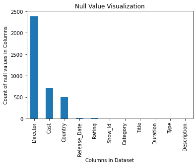

```python
#plot a bargraph of null values
nullvalue= data.isnull().sum()
nullvalue = nullvalue.sort_values(ascending=False)
nullvalue.plot(kind="bar")
plt.xlabel("Columns in Dataset")
plt.ylabel("Count of null values in Columns")
plt.title("Null Value Visualization")
plt.show()
```

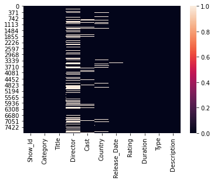

```python
#plot a heat-map using Seaborn
sns.heatmap(data.isnull())
```

We will not treate missing values in this file. Now lets start answering business questions.

# 1- Get detail for "House of Cards" and who is the director of the show.

```python
data[data.Title.isin(["House of Cards"])]
```

|  | Show_Id | Category | Title | Director | Cast | Country | Release_Date | Rating | Duration | Type | Description |
| --- | --- | --- | --- | --- | --- | --- | --- | --- | --- | --- | --- |
| 2832 | s2833 | TV Show | House of Cards | Robin Wright, David Fincher, Gerald McRaney, J... | Kevin Spacey, Robin Wright, Kate Mara, Corey S... | United States | November 2, 2018 | TV-MA | 6 Seasons | TV Dramas, TV Thrillers | A ruthless politician will stop at nothing to ... |

```python
#Director of "House of Cards"
data["Director"][data.Title.isin(["House of Cards"])]
```

```
2832    Robin Wright, David Fincher, Gerald McRaney, J...
Name: Director, dtype: object
```

# 2- Highest number of TV shows and movies released by years, Visualize result.

```python
# all the columns have data type as object. First convert date column to date datatype
#create new column Date_N which include release data.
data["Date_N"] = pd.to_datetime(data["Release_Date"])
data.head()
```

|  | Show_Id | Category | Title | Director | Cast | Country | Release_Date | Rating | Duration | Type | Description | Date_N |
| --- | --- | --- | --- | --- | --- | --- | --- | --- | --- | --- | --- | --- |
| 0 | s1 | TV Show | 3% | NaN | João Miguel, Bianca Comparato, Michel Gomes, R... | Brazil | August 14, 2020 | TV-MA | 4 Seasons | International TV Shows, TV Dramas, TV Sci-Fi &... | In a future where the elite inhabit an island ... | 2020-08-14 |
| 1 | s2 | Movie | 07:19 | Jorge Michel Grau | Demián Bichir, Héctor Bonilla, Oscar Serrano, ... | Mexico | December 23, 2016 | TV-MA | 93 min | Dramas, International Movies | After a devastating earthquake hits Mexico Cit... | 2016-12-23 |
| 2 | s3 | Movie | 23:59 | Gilbert Chan | Tedd Chan, Stella Chung, Henley Hii, Lawrence ... | Singapore | December 20, 2018 | R | 78 min | Horror Movies, International Movies | When an army recruit is found dead, his fellow... | 2018-12-20 |
| 3 | s4 | Movie | 9 | Shane Acker | Elijah Wood, John C. Reilly, Jennifer Connelly... | United States | November 16, 2017 | PG-13 | 80 min | Action & Adventure, Independent Movies, Sci-Fi... | In a postapocalyptic world, rag-doll robots hi... | 2017-11-16 |
| 4 | s5 | Movie | 21 | Robert Luketic | Jim Sturgess, Kevin Spacey, Kate Bosworth, Aar... | United States | January 1, 2020 | PG-13 | 123 min | Dramas | A brilliant group of students become card-coun... | 2020-01-01 |

```python
#check data type of Date_N column
data["Date_N"].dtypes
```

```
dtype('<M8[ns]')
```

```python
# Count number of TV Shows and Movies released by year
year_release_count = data["Date_N"].dt.year.value_counts()
year_release_count= year_release_count.sort_values(ascending=False)
year_release_count
```

```
2019.0    2153
2020.0    2009
2018.0    1685
2017.0    1225
2016.0     443
2021.0     117
2015.0      88
2014.0      25
2011.0      13
2013.0      11
2012.0       3
2009.0       2
2008.0       2
2010.0       1
Name: Date_N, dtype: int64
```

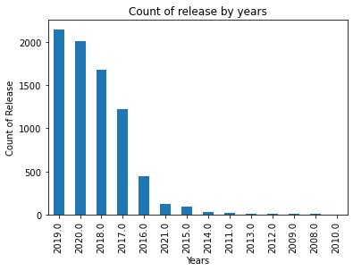

```python
year_release_count.plot(kind="bar")
plt.xlabel("Years")
plt.ylabel("Count of Release")
plt.title("Count of release by years")
plt.show()
```

# 3- How many Movies and TV Show we have in dataset

```python
#Grouping on Category and getting count of unique values
data.groupby("Category").Category.count()
```

```
Category
Movie      5377
TV Show    2410
Name: Category, dtype: int64
```

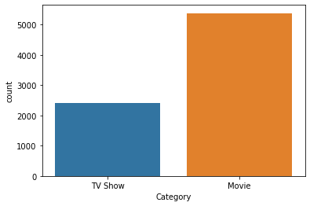

```python
#We can directly olt value count in seaborn countplot() function
sns.countplot(data["Category"])
```

# 4- In The year 2000 how many movies are releases, display their details.

```python
# Create a new column Release_year to extract year from release date
data["Release_year"] = data["Date_N"].dt.year
data.head(3)
```

|  | Show_Id | Category | Title | Director | Cast | Country | Release_Date | Rating | Duration | Type | Description | Date_N | Release_year |
| --- | --- | --- | --- | --- | --- | --- | --- | --- | --- | --- | --- | --- | --- |
| 0 | s1 | TV Show | 3% | NaN | João Miguel, Bianca Comparato, Michel Gomes, R... | Brazil | August 14, 2020 | TV-MA | 4 Seasons | International TV Shows, TV Dramas, TV Sci-Fi &... | In a future where the elite inhabit an island ... | 2020-08-14 | 2020.0 |
| 1 | s2 | Movie | 07:19 | Jorge Michel Grau | Demián Bichir, Héctor Bonilla, Oscar Serrano, ... | Mexico | December 23, 2016 | TV-MA | 93 min | Dramas, International Movies | After a devastating earthquake hits Mexico Cit... | 2016-12-23 | 2016.0 |
| 2 | s3 | Movie | 23:59 | Gilbert Chan | Tedd Chan, Stella Chung, Henley Hii, Lawrence ... | Singapore | December 20, 2018 | R | 78 min | Horror Movies, International Movies | When an army recruit is found dead, his fellow... | 2018-12-20 | 2018.0 |

```python
# filtering data based on requirement where year is 2000 and category is Movie
```

```python
data.head()
```

|  | Show_Id | Category | Title | Director | Cast | Country | Release_Date | Rating | Duration | Type | Description | Date_N | Release_year |
| --- | --- | --- | --- | --- | --- | --- | --- | --- | --- | --- | --- | --- | --- |
| 0 | s1 | TV Show | 3% | NaN | João Miguel, Bianca Comparato, Michel Gomes, R... | Brazil | August 14, 2020 | TV-MA | 4 Seasons | International TV Shows, TV Dramas, TV Sci-Fi &... | In a future where the elite inhabit an island ... | 2020-08-14 | 2020.0 |
| 1 | s2 | Movie | 07:19 | Jorge Michel Grau | Demián Bichir, Héctor Bonilla, Oscar Serrano, ... | Mexico | December 23, 2016 | TV-MA | 93 min | Dramas, International Movies | After a devastating earthquake hits Mexico Cit... | 2016-12-23 | 2016.0 |
| 2 | s3 | Movie | 23:59 | Gilbert Chan | Tedd Chan, Stella Chung, Henley Hii, Lawrence ... | Singapore | December 20, 2018 | R | 78 min | Horror Movies, International Movies | When an army recruit is found dead, his fellow... | 2018-12-20 | 2018.0 |
| 3 | s4 | Movie | 9 | Shane Acker | Elijah Wood, John C. Reilly, Jennifer Connelly... | United States | November 16, 2017 | PG-13 | 80 min | Action & Adventure, Independent Movies, Sci-Fi... | In a postapocalyptic world, rag-doll robots hi... | 2017-11-16 | 2017.0 |
| 4 | s5 | Movie | 21 | Robert Luketic | Jim Sturgess, Kevin Spacey, Kate Bosworth, Aar... | United States | January 1, 2020 | PG-13 | 123 min | Dramas | A brilliant group of students become card-coun... | 2020-01-01 | 2020.0 |

```python
data[(data["Category"]== "Movie") & (data["Release_year"]==2000)]
```

[output not shown]

```python
# No movies were released in the year 2000.
```

```python
#lets check for TV Shoes in year 2000
data[(data["Category"]== "TV Show") & (data["Release_year"]==2000)]
```

|  | Show_Id | Category | Title | Director | Cast | Country | Release_Date | Rating | Duration | Type | Description | Date_N | Release_year |
| --- | --- | --- | --- | --- | --- | --- | --- | --- | --- | --- | --- | --- | --- |

# 5- Show number of TV Shows released in India only and also get their title.

```python
print("Number of TV Shows released in India only are : ",data[(data["Category"]== "TV Show") & (data["Country"]=="India")]["Title"].count())
```

```
Number of TV Shows released in India only are :  71
```

```python
data[(data["Category"]== "TV Show") & (data["Country"]=="India")]["Title"]
```

```
86            21 Sarfarosh: Saragarhi 1897
132                              7 (Seven)
340                           Agent Raghav
364                           Akbar Birbal
533                    Anjaan: Rural Myths
                       ...
6249                  The Creative Indians
6400    The Golden Years with Javed Akhtar
6469                The House That Made Me
7294                            Typewriter
7705                       Yeh Meri Family
Name: Title, Length: 71, dtype: object
```

# 6- Show Top 10 Directors, Who gave the highest number of releases to Netflix.

```python
data["Director"].value_counts().head(10)
```

```
Raúl Campos, Jan Suter    18
Marcus Raboy              16
Jay Karas                 14
Cathy Garcia-Molina       13
Martin Scorsese           12
Jay Chapman               12
Youssef Chahine           12
Steven Spielberg          10
David Dhawan               9
Ryan Polito                8
Name: Director, dtype: int64
```

# 7- Show all the Records, where "Category is Movie and Type is Comedies" or "Country is United Kingdom".

```python
# filter Movie & Comedies
data[(data["Category"]== "Movie") & (data["Type"]=="Comedies") ]
```

|  | Show_Id | Category | Title | Director | Cast | Country | Release_Date | Rating | Duration | Type | Description | Date_N | Release_year |
| --- | --- | --- | --- | --- | --- | --- | --- | --- | --- | --- | --- | --- | --- |
| 33 | s34 | Movie | #realityhigh | Fernando Lebrija | Nesta Cooper, Kate Walsh, John Michael Higgins... | United States | September 8, 2017 | TV-14 | 99 min | Comedies | When nerdy high schooler Dani finally attracts... | 2017-09-08 | 2017.0 |
| 72 | s73 | Movie | 17 Again | Burr Steers | Zac Efron, Leslie Mann, Matthew Perry, Thomas ... | United States | January 1, 2021 | PG-13 | 102 min | Comedies | Nearing a midlife crisis, thirty-something Mik... | 2021-01-01 | 2021.0 |
| 84 | s85 | Movie | 21 & Over | Jon Lucas, Scott Moore | Miles Teller, Skylar Astin, Justin Chon, Sarah... | United States | April 16, 2019 | R | 93 min | Comedies | Jeff's straight-and-narrow life changes abrupt... | 2019-04-16 | 2019.0 |
| 148 | s149 | Movie | A Bad Moms Christmas | Jon Lucas, Scott Moore | Mila Kunis, Kristen Bell, Kathryn Hahn, Susan ... | United States, China | February 14, 2020 | R | 104 min | Comedies | Stressed-out moms Amy, Carla and Kiki are back... | 2020-02-14 | 2020.0 |
| 174 | s175 | Movie | A Futile and Stupid Gesture | David Wain | Will Forte, Domhnall Gleeson, Martin Mull, Joe... | United States | January 26, 2018 | TV-MA | 102 min | Comedies | In a brief life full of triumph and failure, "... | 2018-01-26 | 2018.0 |
| ... | ... | ... | ... | ... | ... | ... | ... | ... | ... | ... | ... | ... | ... |
| 7341 | s7340 | Movie | Undercover Brother 2 | Leslie Small | Michael Jai White, Vince Swann, Barry Bostwick... | United States | November 5, 2019 | R | 85 min | Comedies | When a beloved secret agent falls deep into a ... | 2019-11-05 | 2019.0 |
| 7590 | s7589 | Movie | Where's the Money | Scott Zabielski | Andrew Bachelor, Kat Graham, Mike Epps, Terry ... | United States | January 22, 2018 | R | 86 min | Comedies | Hunting for a stash of stolen money, a sharp-w... | 2018-01-22 | 2018.0 |
| 7623 | s7622 | Movie | Wild Oats | Andy Tennant | Shirley MacLaine, Jessica Lange, Billy Connoll... | Germany, United States | May 13, 2017 | PG-13 | 86 min | Comedies | When insurance accidentally pays her millions,... | 2017-05-13 | 2017.0 |
| 7634 | s7633 | Movie | Wine Country | Amy Poehler | Amy Poehler, Maya Rudolph, Ana Gasteyer, Rache... | United States | May 10, 2019 | R | 104 min | Comedies | When longtime friends meet up for a wine-soake... | 2019-05-10 | 2019.0 |
| 7664 | s7663 | Movie | Work It | Laura Terruso | Sabrina Carpenter, Jordan Fisher, Liza Koshy, ... | United States | August 7, 2020 | TV-14 | 94 min | Comedies | A brilliant but clumsy high school senior vows... | 2020-08-07 | 2020.0 |

97 rows × 13 columns

```python
#First condition & then second condition then / "Or" condition
data[(data["Category"]== "Movie") & (data["Type"]=="Comedies") | (data["Country"]== "United Kingdom")]
```

|  | Show_Id | Category | Title | Director | Cast | Country | Release_Date | Rating | Duration | Type | Description | Date_N | Release_year |
| --- | --- | --- | --- | --- | --- | --- | --- | --- | --- | --- | --- | --- | --- |
| 19 | s20 | Movie | '89 | NaN | Lee Dixon, Ian Wright, Paul Merson | United Kingdom | May 16, 2018 | TV-PG | 87 min | Sports Movies | Mixing old footage with interviews, this is th... | 2018-05-16 | 2018.0 |
| 33 | s34 | Movie | #realityhigh | Fernando Lebrija | Nesta Cooper, Kate Walsh, John Michael Higgins... | United States | September 8, 2017 | TV-14 | 99 min | Comedies | When nerdy high schooler Dani finally attracts... | 2017-09-08 | 2017.0 |
| 58 | s59 | TV Show | 100% Hotter | NaN | Daniel Palmer, Melissa Sophia, Karen Williams,... | United Kingdom | November 1, 2019 | TV-14 | 1 Season | British TV Shows, International TV Shows, Real... | A stylist, a hair designer and a makeup artist... | 2019-11-01 | 2019.0 |
| 72 | s73 | Movie | 17 Again | Burr Steers | Zac Efron, Leslie Mann, Matthew Perry, Thomas ... | United States | January 1, 2021 | PG-13 | 102 min | Comedies | Nearing a midlife crisis, thirty-something Mik... | 2021-01-01 | 2021.0 |
| 82 | s83 | Movie | 2036 Origin Unknown | Hasraf Dulull | Katee Sackhoff, Ray Fearon, Julie Cox, Steven ... | United Kingdom | December 20, 2018 | TV-14 | 95 min | Sci-Fi & Fantasy | Working with an artificial intelligence to inv... | 2018-12-20 | 2018.0 |
| ... | ... | ... | ... | ... | ... | ... | ... | ... | ... | ... | ... | ... | ... |
| 7670 | s7669 | TV Show | World War II in Colour | NaN | Robert Powell | United Kingdom | August 1, 2017 | TV-MA | 1 Season | British TV Shows, Docuseries, International TV... | Footage of the most dramatic moments from Worl... | 2017-08-01 | 2017.0 |
| 7671 | s7670 | TV Show | World's Busiest Cities | NaN | Anita Rani, Ade Adepitan, Dan Snow | United Kingdom | February 1, 2019 | TV-PG | 1 Season | British TV Shows, Docuseries | From Moscow to Mexico City, three BBC journali... | 2019-02-01 | 2019.0 |
| 7688 | s7687 | Movie | XV: Beyond the Tryline | Pierre Deschamps | NaN | United Kingdom | March 18, 2020 | TV-14 | 91 min | Documentaries, Sports Movies | Set against the 2015 Rugby World Cup, this doc... | 2020-03-18 | 2020.0 |
| 7725 | s7724 | Movie | You Can Tutu | James Brown | Lily O'Regan, Jeannettsy Enriquez Borges, Joel... | United Kingdom | December 31, 2017 | TV-G | 87 min | Children & Family Movies | A gifted young ballet dancer struggles to find... | 2017-12-31 | 2017.0 |
| 7740 | s7739 | TV Show | Young Wallander | NaN | Adam Pålsson, Richard Dillane, Leanne Best, El... | United Kingdom | September 3, 2020 | TV-MA | 1 Season | Crime TV Shows, International TV Shows, TV Dramas | An incendiary hate crime stirs civil unrest, f... | 2020-09-03 | 2020.0 |

485 rows × 13 columns

# 8- Get detail of Actor Tom Cruise, in home many Movies/Shows he was present.

```python
#As our data cntains NaN values we can not search for Tom Cruise directly
#Lets create a new df and drop NaN values first to filter record based on conditions.
data_t = data.copy()
data_t["Cast"].isnull().sum()
```

```
718
```

```python
#Drop Nan values
data_t.dropna(inplace=True)
data_t["Cast"].isnull().sum()
```

```
0
```

```python
data_t[data_t["Cast"].str.contains("Tom Cruise")]
```

|  | Show_Id | Category | Title | Director | Cast | Country | Release_Date | Rating | Duration | Type | Description | Date_N | Release_year |
| --- | --- | --- | --- | --- | --- | --- | --- | --- | --- | --- | --- | --- | --- |
| 3860 | s3861 | Movie | Magnolia | Paul Thomas Anderson | Jeremy Blackman, Tom Cruise, Melinda Dillon, A... | United States | January 1, 2020 | R | 189 min | Dramas, Independent Movies | Through chance, human action, past history and... | 2020-01-01 | 2020.0 |
| 5071 | s5071 | Movie | Rain Man | Barry Levinson | Dustin Hoffman, Tom Cruise, Valeria Golino, Ge... | United States | July 1, 2019 | R | 134 min | Classic Movies, Dramas | A fast-talking yuppie is forced to slow down w... | 2019-07-01 | 2019.0 |

# 9- Count of all unique Ratings .

```python
# type of rating we have in dataset
print("We have total",data["Rating"].nunique(),"type of ratings from Netflix.")
```

```
We have total 14 type of ratings from Netflix.
```

```python
#unique values in rating
data["Rating"].unique()
```

```
array(['TV-MA', 'R', 'PG-13', 'TV-14', 'TV-PG', 'NR', 'TV-G', 'TV-Y', nan,
       'TV-Y7', 'PG', 'G', 'NC-17', 'TV-Y7-FV', 'UR'], dtype=object)
```

```python
#value count of each type of Rating
data["Rating"].value_counts()
```

```
TV-MA       2863
TV-14       1931
TV-PG        806
R            665
PG-13        386
TV-Y         280
TV-Y7        271
PG           247
TV-G         194
NR            84
G             39
TV-Y7-FV       6
UR             5
NC-17          3
Name: Rating, dtype: int64
```

# 10- Get the count of TV-14 rating Movies in Canada.

```python
print("There are total",data[(data["Rating"]=="TV-14") & (data["Category"]=="Movie")& (data["Country"]== "Canada")].Title.count(),"Movies with TV-14 rating in Canada.")
#data[(data["Rating"]=="TV-14") & (data["Country"]== "Canada")].shape[0] for getting count
print("  Title of Movies with TV-14 Rating  ")
data[(data["Rating"]=="TV-14") & (data["Category"]=="Movie") & (data["Country"]== "Canada")].Title
```

```
There are total 11 Movies with TV-14 rating in Canada.
  Title of Movies with TV-14 Rating
```

```
30                                 #cats_the_mewvie
34                                            #Roxy
608                                  At First Light
1506                     Counterfeiting in Suburbia
3713                              Long Time Running
3956    Martin Matte: La vie, la mort...eh la la..!
5336                     Sadie's Last Days on Earth
5393                                     Sardaar ji
6062                    The Accountant of Auschwitz
7025                           The Wrong Babysitter
7041                 There's Something in the Water
Name: Title, dtype: object
```

# 11- After 2018 how many TV Shows got "R" rating.

```python
print("There are total",data[(data["Category"]=="TV Show")&(data["Rating"]=="R") & (data["Release_year"]> 2018)].shape[0],"TV Shows with R rating after 2018.")
data[(data["Category"]=="TV Show")&(data["Rating"]=="R") & (data["Release_year"]> 2018)].Title
```

```
There are total 1 TV Shows with R rating after 2018.
```

```
6437    The Hateful Eight: Extended Version
Name: Title, dtype: object
```

# 12- Maximum Seasons in TV Shows.

```python
#check values in Duration
data["Duration"].unique()
```

```
array(['4 Seasons', '93 min', '78 min', '80 min', '123 min', '1 Season',
       '95 min', '119 min', '118 min', '143 min', '103 min', '89 min',
       '91 min', '149 min', '144 min', '124 min', '87 min', '110 min',
       '128 min', '117 min', '100 min', '2 Seasons', '84 min', '99 min',
       '90 min', '102 min', '104 min', '105 min', '56 min', '125 min',
       '81 min', '97 min', '106 min', '107 min', '109 min', '44 min',
       '75 min', '101 min', '3 Seasons', '37 min', '113 min', '114 min',
       '130 min', '94 min', '140 min', '135 min', '82 min', '70 min',
       '121 min', '92 min', '164 min', '53 min', '83 min', '116 min',
       '86 min', '120 min', '96 min', '126 min', '129 min', '77 min',
       '137 min', '148 min', '28 min', '122 min', '176 min', '85 min',
       '22 min', '68 min', '111 min', '29 min', '142 min', '168 min',
       '21 min', '59 min', '20 min', '98 min', '108 min', '76 min',
       '26 min', '156 min', '30 min', '57 min', '150 min', '133 min',
       '115 min', '154 min', '127 min', '146 min', '136 min', '88 min',
       '131 min', '24 min', '112 min', '74 min', '63 min', '38 min',
       '25 min', '174 min', '60 min', '153 min', '158 min', '151 min',
       '162 min', '54 min', '51 min', '69 min', '64 min', '147 min',
       '42 min', '79 min', '5 Seasons', '40 min', '45 min', '172 min',
       '10 min', '163 min', '9 Seasons', '55 min', '72 min', '61 min',
       '71 min', '160 min', '171 min', '48 min', '139 min', '157 min',
       '15 min', '65 min', '134 min', '161 min', '62 min', '8 Seasons',
       '186 min', '49 min', '73 min', '58 min', '165 min', '166 min',
       '138 min', '159 min', '141 min', '132 min', '52 min', '67 min',
       '34 min', '66 min', '312 min', '180 min', '47 min', '6 Seasons',
       '155 min', '14 min', '177 min', '11 min', '9 min', '46 min',
       '145 min', '11 Seasons', '7 Seasons', '13 Seasons', '8 min',
       '12 min', '12 Seasons', '10 Seasons', '43 min', '50 min', '23 min',
       '185 min', '200 min', '169 min', '27 min', '170 min', '196 min',
       '33 min', '181 min', '204 min', '32 min', '35 min', '167 min',
       '16 Seasons', '179 min', '193 min', '13 min', '214 min', '17 min',
       '173 min', '192 min', '209 min', '187 min', '41 min', '182 min',
       '224 min', '233 min', '189 min', '152 min', '19 min', '15 Seasons',
       '208 min', '237 min', '31 min', '178 min', '230 min', '194 min',
       '228 min', '195 min', '3 min', '16 min', '5 min', '18 min',
       '205 min', '190 min', '36 min', '201 min', '253 min', '203 min',
       '191 min'], dtype=object)
```

```python
# values in the column are of Object type. lest split the values and store them in new columns
data[["Minuts","Unit"]]= data["Duration"].str.split(' ',expand=True)
data.head()
```

|  | Show_Id | Category | Title | Director | Cast | Country | Release_Date | Rating | Duration | Type | Description | Date_N | Release_year | Minuts | Unit |
| --- | --- | --- | --- | --- | --- | --- | --- | --- | --- | --- | --- | --- | --- | --- | --- |
| 0 | s1 | TV Show | 3% | NaN | João Miguel, Bianca Comparato, Michel Gomes, R... | Brazil | August 14, 2020 | TV-MA | 4 Seasons | International TV Shows, TV Dramas, TV Sci-Fi &... | In a future where the elite inhabit an island ... | 2020-08-14 | 2020.0 | 4 | Seasons |
| 1 | s2 | Movie | 07:19 | Jorge Michel Grau | Demián Bichir, Héctor Bonilla, Oscar Serrano, ... | Mexico | December 23, 2016 | TV-MA | 93 min | Dramas, International Movies | After a devastating earthquake hits Mexico Cit... | 2016-12-23 | 2016.0 | 93 | min |
| 2 | s3 | Movie | 23:59 | Gilbert Chan | Tedd Chan, Stella Chung, Henley Hii, Lawrence ... | Singapore | December 20, 2018 | R | 78 min | Horror Movies, International Movies | When an army recruit is found dead, his fellow... | 2018-12-20 | 2018.0 | 78 | min |
| 3 | s4 | Movie | 9 | Shane Acker | Elijah Wood, John C. Reilly, Jennifer Connelly... | United States | November 16, 2017 | PG-13 | 80 min | Action & Adventure, Independent Movies, Sci-Fi... | In a postapocalyptic world, rag-doll robots hi... | 2017-11-16 | 2017.0 | 80 | min |
| 4 | s5 | Movie | 21 | Robert Luketic | Jim Sturgess, Kevin Spacey, Kate Bosworth, Aar... | United States | January 1, 2020 | PG-13 | 123 min | Dramas | A brilliant group of students become card-coun... | 2020-01-01 | 2020.0 | 123 | min |

```python
#Convert Minuts Column to integer
data["Minuts"]=pd.to_numeric(data["Minuts"])
data["Minuts"].dtype
```

[output not shown]

```python
# duration of TV Show in terms of season
print("Seasons wise TV Show count",data[data["Category"]=="TV Show"].Duration.value_counts())
```

```
Seasons wise TV Show count 1 Season      1608
2 Seasons      382
3 Seasons      184
4 Seasons       87
5 Seasons       58
6 Seasons       30
7 Seasons       19
8 Seasons       18
9 Seasons        8
10 Seasons       6
11 Seasons       3
12 Seasons       2
13 Seasons       2
15 Seasons       2
16 Seasons       1
Name: Duration, dtype: int64
```

```python
# Maximum Seasons in TV Show
print("Maximum Seasons in TV Show is",data[data["Category"]=="TV Show"].Minuts.max(),"Seasons.")
```

```
Maximum Seasons in TV Show is 16 Seasons.
```

# 13- Maximum duration in Moive.

```python
# Maximum Duration of Movie
print("Maximum duration in Movie is",data[data["Category"]=="Movie"].Minuts.max(),"minuts.")
```

```
Maximum duration in Movie is 312 minuts.
```

# 14 Country with release of maximum number of TV Show.

```python
#Country with maximum TV Shows
data[data["Category"]=="TV Show"].Country.value_counts().head(1)
```

```
United States    705
Name: Country, dtype: int64
```

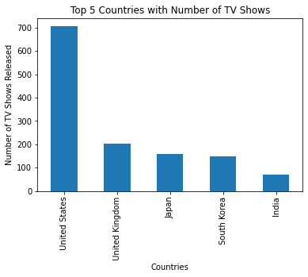

```python
# Top 5 Countries in terms of shows
data[data["Category"]=="TV Show"].Country.value_counts().head(5).plot(kind="bar")
plt.xlabel("Countries")
plt.ylabel("Number of TV Shows Released")
plt.title("Top 5 Countries with Number of TV Shows")
plt.show()
```

# 15 Country with release of maximum number of movies.

```python
data[data["Category"]=="Movie"].Country.value_counts().head(1)
```

```
United States    1850
Name: Country, dtype: int64
```

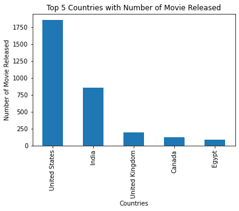

```python
# Top 5 Countries in terms of Movie released
data[data["Category"]=="Movie"].Country.value_counts().head(5).plot(kind="bar")
plt.xlabel("Countries")
plt.ylabel("Number of Movie Released")
plt.title("Top 5 Countries with Number of Movie Released")
plt.show()
```

# 16 Find total number of Drama Movies and display records.

```python
#Count of Drama Movies
print("Total Number of Drama Movies",data[(data["Category"]=="Movie") & data["Type"].str.contains("Dramas")].shape[0],".")
```

```
Total Number of Drama Movies 2106 .
```

```python
# Drama movie records
data[(data["Category"]=="Movie") & data["Type"].str.contains("Dramas")]
```

|  | Show_Id | Category | Title | Director | Cast | Country | Release_Date | Rating | Duration | Type | Description | Date_N | Release_year | Minuts | Unit |
| --- | --- | --- | --- | --- | --- | --- | --- | --- | --- | --- | --- | --- | --- | --- | --- |
| 1 | s2 | Movie | 07:19 | Jorge Michel Grau | Demián Bichir, Héctor Bonilla, Oscar Serrano, ... | Mexico | December 23, 2016 | TV-MA | 93 min | Dramas, International Movies | After a devastating earthquake hits Mexico Cit... | 2016-12-23 | 2016.0 | 93 | min |
| 4 | s5 | Movie | 21 | Robert Luketic | Jim Sturgess, Kevin Spacey, Kate Bosworth, Aar... | United States | January 1, 2020 | PG-13 | 123 min | Dramas | A brilliant group of students become card-coun... | 2020-01-01 | 2020.0 | 123 | min |
| 7 | s8 | Movie | 187 | Kevin Reynolds | Samuel L. Jackson, John Heard, Kelly Rowan, Cl... | United States | November 1, 2019 | R | 119 min | Dramas | After one of his high school students attacks ... | 2019-11-01 | 2019.0 | 119 | min |
| 10 | s11 | Movie | 1922 | Zak Hilditch | Thomas Jane, Molly Parker, Dylan Schmid, Kaitl... | United States | October 20, 2017 | TV-MA | 103 min | Dramas, Thrillers | A farmer pens a confession admitting to his wi... | 2017-10-20 | 2017.0 | 103 | min |
| 15 | s16 | Movie | Oct-01 | Kunle Afolayan | Sadiq Daba, David Bailie, Kayode Olaiya, Kehin... | Nigeria | September 1, 2019 | TV-14 | 149 min | Dramas, International Movies, Thrillers | Against the backdrop of Nigeria's looming inde... | 2019-09-01 | 2019.0 | 149 | min |
| ... | ... | ... | ... | ... | ... | ... | ... | ... | ... | ... | ... | ... | ... | ... | ... |
| 7776 | s7775 | Movie | Zodiac | David Fincher | Mark Ruffalo, Jake Gyllenhaal, Robert Downey J... | United States | November 20, 2019 | R | 158 min | Cult Movies, Dramas, Thrillers | A political cartoonist, a crime reporter and a... | 2019-11-20 | 2019.0 | 158 | min |
| 7778 | s7777 | Movie | Zokkomon | Satyajit Bhatkal | Darsheel Safary, Anupam Kher, Manjari Fadnis, ... | India | November 1, 2018 | PG | 104 min | Children & Family Movies, Dramas | When his cruel uncle abandons him, a young orp... | 2018-11-01 | 2018.0 | 104 | min |
| 7782 | s7781 | Movie | Zoo | Shlok Sharma | Shashank Arora, Shweta Tripathi, Rahul Kumar, ... | India | July 1, 2018 | TV-MA | 94 min | Dramas, Independent Movies, International Movies | A drug dealer starts having doubts about his t... | 2018-07-01 | 2018.0 | 94 | min |
| 7784 | s7783 | Movie | Zozo | Josef Fares | Imad Creidi, Antoinette Turk, Elias Gergi, Car... | Sweden, Czech Republic, United Kingdom, Denmar... | October 19, 2020 | TV-MA | 99 min | Dramas, International Movies | When Lebanon's Civil War deprives Zozo of his ... | 2020-10-19 | 2020.0 | 99 | min |
| 7785 | s7784 | Movie | Zubaan | Mozez Singh | Vicky Kaushal, Sarah-Jane Dias, Raaghav Chanan... | India | March 2, 2019 | TV-14 | 111 min | Dramas, International Movies, Music & Musicals | A scrappy but poor boy worms his way into a ty... | 2019-03-02 | 2019.0 | 111 | min |

2106 rows × 15 columns

# 17- Find total number of Kids TV Show and display records.

```python
#Count of Drama Movies
print("Total Number of Kids TV Shows",data[(data["Category"]=="TV Show") & data["Type"].str.contains("Kids")].shape[0],".")
```

```
Total Number of Kids TV Shows 414 .
```

```python
# Kids TV Shows
data[(data["Category"]=="TV Show") & data["Type"].str.contains("Kids")]
```

|  | Show_Id | Category | Title | Director | Cast | Country | Release_Date | Rating | Duration | Type | Description | Date_N | Release_year | Minuts | Unit |
| --- | --- | --- | --- | --- | --- | --- | --- | --- | --- | --- | --- | --- | --- | --- | --- |
| 108 | s109 | TV Show | 3Below: Tales of Arcadia | NaN | Tatiana Maslany, Diego Luna, Nick Offerman, Ni... | United States | July 12, 2019 | TV-Y7 | 2 Seasons | Kids' TV, TV Action & Adventure, TV Sci-Fi & F... | After crash-landing on Earth, two royal teen a... | 2019-07-12 | 2019.0 | 2 | Seasons |
| 111 | s112 | TV Show | 44 Cats | NaN | Sarah Natochenny, Suzy Myers, Simona Berman, E... | Italy | October 1, 2020 | TV-Y7 | 2 Seasons | Kids' TV | Paw-esome tales abound when singing furry frie... | 2020-10-01 | 2020.0 | 2 | Seasons |
| 225 | s226 | TV Show | A Series of Unfortunate Events | NaN | Neil Patrick Harris, Patrick Warburton, Malina... | United States | January 1, 2019 | TV-PG | 3 Seasons | Kids' TV, TV Action & Adventure, TV Comedies | The extraordinary Baudelaire orphans face tria... | 2019-01-01 | 2019.0 | 3 | Seasons |
| 276 | s277 | TV Show | Abby Hatcher | Kyran Kelly | Macy Drouin, Wyatt White, Paul Sun-Hyung Lee, ... | United States, Canada | July 1, 2020 | TV-Y | 1 Season | Kids' TV | A big-hearted girl helps her Fuzzly friends wh... | 2020-07-01 | 2020.0 | 1 | Season |
| 364 | s365 | TV Show | Akbar Birbal | NaN | Kiku Sharda, Vishal Kotian, Delnaaz Irani | India | March 31, 2020 | TV-G | 1 Season | Kids' TV, TV Comedies, TV Dramas | From battles of wit to fights for justice, Emp... | 2020-03-31 | 2020.0 | 1 | Season |
| ... | ... | ... | ... | ... | ... | ... | ... | ... | ... | ... | ... | ... | ... | ... | ... |
| 7758 | s7757 | TV Show | Z4 | NaN | Apollo Costa, Gabriel Santana, Matheus Lustosa... | Brazil | February 22, 2019 | TV-PG | 2 Seasons | Kids' TV | Fading music biz veteran Zé realizes he has ju... | 2019-02-22 | 2019.0 | 2 | Seasons |
| 7761 | s7760 | TV Show | Zak Storm | NaN | Michael Johnston, Jessica Gee-George, Christin... | United States, France, South Korea, Indonesia | September 13, 2018 | TV-Y7 | 3 Seasons | Kids' TV | Teen surfer Zak Storm is mysteriously transpor... | 2018-09-13 | 2018.0 | 3 | Seasons |
| 7768 | s7767 | TV Show | Zig & Sharko | NaN | NaN | France | December 1, 2017 | TV-Y7 | 1 Season | Kids' TV, TV Comedies | Zig, an island-bound hyena, will do anything t... | 2017-12-01 | 2017.0 | 1 | Season |
| 7777 | s7776 | TV Show | Zoids Wild | NaN | Kensho Ono, Takahiro Sakurai, Mikako Komatsu, ... | Japan | August 14, 2020 | TV-Y7 | 1 Season | Anime Series, Kids' TV | A quest for freedom and legendary treasure beg... | 2020-08-14 | 2020.0 | 1 | Season |
| 7779 | s7778 | TV Show | Zombie Dumb | NaN | NaN | NaN | July 1, 2019 | TV-Y7 | 2 Seasons | Kids' TV, Korean TV Shows, TV Comedies | While living alone in a spooky town, a young g... | 2019-07-01 | 2019.0 | 2 | Seasons |

414 rows × 15 columns

# 18- Find the number of Comedy Movies released for family and kids in india only and display their title.

```python
# number of Comedy Movies released for family and kids in india only.
print(data[(data["Category"]=="Movie")& (data["Country"]=="India") & (data["Type"].str.contains('Comedies|Family|Kids'))].shape[0],"comedy movie released in India for kids and family.")
```

```
303 comedy movie released in India for kids and family.
```

```python
# Title of comedy movies released for kids and family in india
print("Title of comedy movies released for kids and family in india")
data[(data["Category"]=="Movie")& (data["Country"]=="India") & (data["Type"].str.contains('Comedies|Family|Kids'))].Title
```

```
Title of comedy movies released for kids and family in india
```

```
18                        15-Aug
78                      2 States
100                     3 Idiots
143                        90 ML
244            A truthful Mother
                  ...
7704            Yeh Hai Bakrapur
7764                    Zed Plus
7766                        Zero
7771    Zindagi Na Milegi Dobara
7778                    Zokkomon
Name: Title, Length: 303, dtype: object
```

# 19- Find the number of adult movies released in india only along with title and duration of movie.

```python
#number of adult movies released in india only along with title and duration of movie.
print(data[(data["Category"]=="Movie")& (data["Country"]=="India") & (data["Type"].str.contains('Adult'))].shape[0],"adult movie released in India.")
```

```
0 adult movie released in India.
```

# 20- Find Adventure and Thriller movies released in india only along with title and duration of movie.

```python
# number of Thriller, Action and Adventure movies in india
print(data[(data["Category"]=="Movie")& (data["Country"]=="India") & (data["Type"].str.contains('Adventure|Action|Thriller'))].Title.shape[0],"Thriller, Action and Adventure movie released in India.")
```

```
209 Thriller, Action and Adventure movie released in India.
```

```python
# Title of Thriller, Action and Adventure movies in india
print("Title of Thriller, Action and Adventure movie released in India\n",data[(data["Category"]=="Movie")& (data["Country"]=="India") & (data["Type"].str.contains('Adventure|Action|Thriller'))].Title)
```

```
Title of Thriller, Action and Adventure movie released in India
 9                        1920
21               Goli Soda 2
90                   25 Kille
129                     6-5=2
136              7 Khoon Maaf
                ...
7442            Vodka Diaries
7453                  W/O Ram
7456         Waarrior Savitri
7496                    Wazir
7698    Yamla Pagla Deewana 2
Name: Title, Length: 209, dtype: object
```